# A_test_file_for_Git_and_Github

Moran(Raymond) Guo

2024-09-01

Aug 29th Class Note – Edited Sep 1st

1. Why we want to use **Version Control**?

If we change file name every time we change a document, we will have a long list of files with different formats of names.

**So that’s why.**

Git also allow us to track the date and amount of changes made previously by different people.

Git is useful for files that are text files, such as LaTeX, HTML, and/or R scripts. Less useful for PDF files, Powerpoint, etc., in which case you might consider using Google Drive/OneDrive.

Pull: Download anything new from the cloud;

Push: Upload anything you modified to the cloud.

2. Reproducible research.

We need to try to reproduce a work, or a work need to be considerably reproducible/replicable for other researchers. Reproducibility includes: Computational reproducibility, Empirical reproducibility, and Statistical reproducibility.

3. `here` and `sessioninfo` package

`here` package allows us to better manage file paths, especially when sharing code with different people.

```r
here::here()
```

```
## [1] "/Users/raymond/JHSPH_Stat_Computing"
```

```r
here::here("here_example", "test.R")
```

```
## [1] "/Users/raymond/JHSPH_Stat_Computing/here_example/test.R"
```

```r
full_path <- "/Users/raymond/JHSPH_Stat_Computing/here_example/test.R"
```

This could avoid that when sharing code with others, they might not have username `Raymond` or folder name `JHSPH_Stat_Computing`, but the sub-folder name is the same.

It also has `pyhere` package as an equivalent version of Python package.

```r
print('Reprodicibility Information:')
```

```
## [1] "Reprodicibility Information:"
```

```r
Sys.time()
```

```
## [1] "2024-09-01 15:12:06 EDT"
```

```r
proc.time()
```

```
##    user  system elapsed
##   0.178   0.046   0.393
```

```r
options(width = 120)
```

4. Literate programming

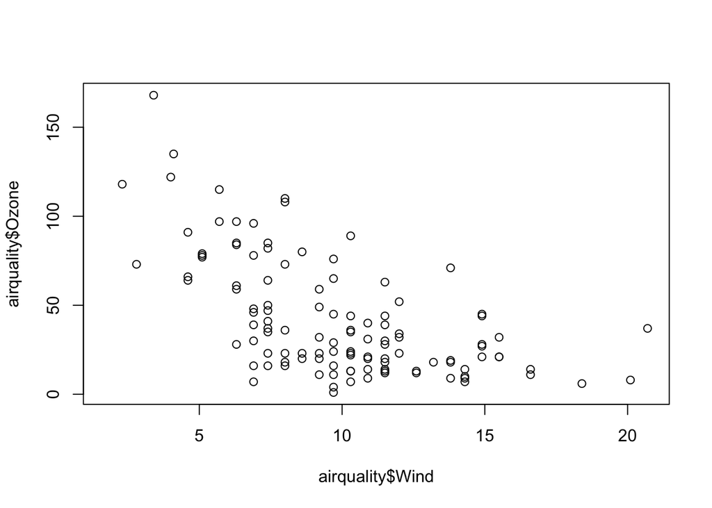

```r
data(airquality)
plot(airquality$Ozone ~ airquality$Wind)
```